# Part II - (Prosper Loan Dataset)

## by (Andrew Bernard Ngari Mwangi)

## Investigation Overview

My goal is to investigate about the borrowers alpha prosper ratings and where the majority of those borrowers lay. Get to determine the stated monthly income of the borrowers and how the increase in the number of loans original amount affected the number of investors. I also want to know how the verification of the borrowers affects the number of investors in a particular listing. I'm also interested in knowing how the number of investors are affected by the borrowers original loan amount and how the two relate with the monthly loan payments.

Here are the key insights in my slide show:

The dataset contains 113937 rows and 81 columns most of which have numerical type data. Other columns have the categorical type data while others have a date-time type data.

The unique column being that of listing keys and so I'm going to drop duplicates if there are any.

## (Visualization 1)

Over 17500 of the borrowers had an alpha prosper rating of C at 21.55% making them the majority while the least number of borrowers of just over 5000 had an alpha prosper rating of AA at 6.34%. Majority of the borrowers lay between the ratings of A, B, C and D amounting to 73.85%.

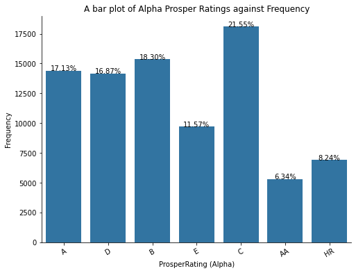

## (Visualization 2)

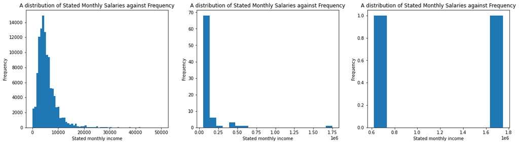

## (Visualization 3)

An increase in the number of the loans original amount seemed to have increased the number of investors lending borrowers loans.A small number of investors seem to have been investing in borrowers who needed a small amount of money lent to them while borrowers who needed a larger sum of money lent to them attracted a larger number of investors.

Most of the borrowers are those who needed less than $\$30,000$ depicted by the figure shown hereafter.

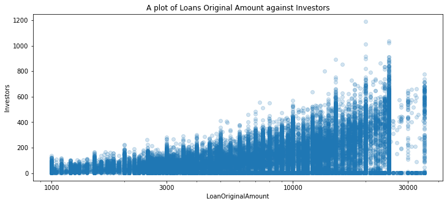

## (Visualization 4)

600 or more investors lent money to borrowers who had a verifiable source(s) of income. Only one borrower who made a monthly payment of above 1500 had an unverified source(s) of income.

Majority of borrowers who did not have a verifiable source(s) of income had less than 400 investors lending them money. Of those investors, a majority of them made less than $\$600$ monthly loan payments.

For every level of monthly loan payments, those who had a verifiable source(s) of income had the most number of investors lending them money compared to those with unverified source(s) of income.

All borrowers who made more than $\$810$ and had only one investor lending them money had their source(s) of income verified.

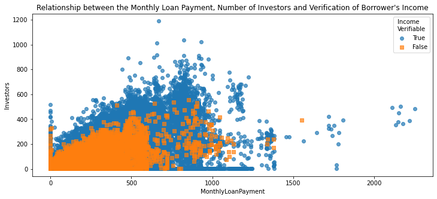

## (Visualization 5)

The number of investors in the state with the most number of borrowers increases with an increase in the number of loan original amount. Borrowers with a higher loan original amount were making more monthly loan payments and had a larger number of investors as compared to borrowers with a smaller loan original amount.

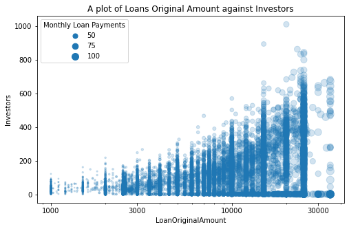